# Modelling uncertainty in R₀

Epidemic final size calculations are sensitive to input data such as the $R_0$ of the infection. Such values can often be uncertain in the early stages of an outbreak. This uncertainty can be included in final size calculations by running `final_size()` for values drawn from a distribution, and summarising the outcomes.

**New to *finalsize*?** It may help to read the “Get started”, “Modelling heterogeneous contacts”, or “Modelling heterogeneous susceptibility” vignettes first!

## Use case

The infection **parameter ($R_0$) is uncertain**. We want to know how much variation this could cause in the estimated final size of the epidemic.

### What we have

1. In addition to the $R_0$, demography data, social contact data, and data on the distribution of susceptibility among age groups;
2. A measure of the error in the estimated $R_0$ of the infection.

### What we assume

1. An SIR epidemic, and the complete partitioning of individuals into different demographic and infection risk groups.

```r
# load finalsize
library(finalsize)
library(socialmixr)
library(ggplot2)
```

## Getting $R_0$, contact and demography data, and susceptibility

This example uses social contact data from the POLYMOD project (Mossong et al. 2008) to estimate the final size of an epidemic in the U.K. These data are provided with the `socialmixr` package.

These data are handled just as in the “Get started” vignette. This example also considers an infection with an $R_0$ of 1.5.

```r
# get UK polymod data from socialmixr
polymod <- socialmixr::polymod
contact_data <- socialmixr::contact_matrix(
  polymod,
  countries = "United Kingdom",
  age.limits = c(0, 5, 18, 40, 65),
  symmetric = TRUE
)

# get the contact matrix and demography data
contact_matrix <- t(contact_data$matrix)
demography_vector <- contact_data$demography$population

# scale the contact matrix so the largest eigenvalue is 1.0
contact_matrix <- contact_matrix / max(Re(eigen(contact_matrix)$values))

# divide each row of the contact matrix by the corresponding demography
contact_matrix <- contact_matrix / demography_vector

n_demo_grps <- length(demography_vector)
```

```r
# mean R0 is 1.5
r0_mean <- 1.5
```

For simplicity, this example considers a scenario in which susceptibility to infection does not vary.

```r
# susceptibility is uniform
susc_uniform <- matrix(
  data = 1,
  nrow = n_demo_grps,
  ncol = 1L
)

# p_susceptibility is uniform
p_susc_uniform <- susc_uniform
```

## Running `final_size` over $R_0$ samples

The basic reproduction number $R_0$ of an infection might be uncertain in the early stages of an epidemic. This uncertainty can be modelled by running `final_size()` multiple times for the same contact, demography, and susceptibility data, while sampling $R_0$ values from a distribution.

This example assumes that the $R_0$ estimate, and the uncertainty around that estimate, is provided as the mean and standard deviation of a normal distribution.

This example considers a normal distribution $N(\mu = 1.5, \sigma = 0.1)$, for an $R_0$ of 1.5. We can draw 1,000 $R_0$ samples from this distribution and run `final_size()` on the contact data and demography data for each sample.

This is quick, as `finalsize` is an Rcpp package with a C++ backend.

```r
# create an R0 samples vector
r0_samples <- rnorm(n = 1000, mean = r0_mean, sd = 0.1)
```

### Iterate final_size()

#### With base R

```r
# run final size on each sample with the same data
final_size_data <- Map(
  r0_samples, seq_along(r0_samples),
  f = function(r0, i) {
    # the i-th final size estimate
    fs <- final_size(
      r0 = r0,
      contact_matrix = contact_matrix,
      demography_vector = demography_vector,
      susceptibility = susc_uniform,
      p_susceptibility = p_susc_uniform
    )

    fs$replicate <- i
    fs$r0_estimate <- r0
    fs
  }
)

# combine data
final_size_data <- Reduce(x = final_size_data, f = rbind)

# order age groups
final_size_data$demo_grp <- factor(
  final_size_data$demo_grp,
  levels = contact_data$demography$age.group
)

# examine some replicates in the data
head(final_size_data, 15)
```

```
#>    demo_grp   susc_grp susceptibility p_infected replicate r0_estimate
#> 1     [0,5) susc_grp_1              1  0.2828070         1    1.305846
#> 2    [5,18) susc_grp_1              1  0.5289646         1    1.305846
#> 3   [18,40) susc_grp_1              1  0.3789743         1    1.305846
#> 4   [40,65) susc_grp_1              1  0.3173551         1    1.305846
#> 5       65+ susc_grp_1              1  0.1972185         1    1.305846
#> 6     [0,5) susc_grp_1              1  0.4321346         2    1.526937
#> 7    [5,18) susc_grp_1              1  0.7054231         2    1.526937
#> 8   [18,40) susc_grp_1              1  0.5561065         2    1.526937
#> 9   [40,65) susc_grp_1              1  0.4813572         2    1.526937
#> 10      65+ susc_grp_1              1  0.3178570         2    1.526937
#> 11    [0,5) susc_grp_1              1  0.3671955         3    1.423220
#> 12   [5,18) susc_grp_1              1  0.6350977         3    1.423220
#> 13  [18,40) susc_grp_1              1  0.4813138         3    1.423220
#> 14  [40,65) susc_grp_1              1  0.4106077         3    1.423220
#> 15      65+ susc_grp_1              1  0.2638501         3    1.423220
```

#### With {tidyverse}

```r
library(tibble)
library(dplyr)
library(tidyr)
library(purrr)
library(forcats)

final_size_data <-
  # create a dataframe with values from a vector
  tibble(r0 = r0_samples) %>%
  rownames_to_column() %>%
  # map the function final_size() to all the r0 values
  # with the same set of arguments
  # with {purrr}
  mutate(
    temp = map(
      .x = r0,
      .f = final_size,
      contact_matrix = contact_matrix,
      demography_vector = demography_vector,
      susceptibility = susc_uniform,
      p_susceptibility = p_susc_uniform
    )
  ) %>%
  # unnest all the dataframe outputs in temp
  unnest(temp) %>%
  # relevel the factor variable
  mutate(
    demo_grp = fct_relevel(
      demo_grp,
      contact_data %>%
        pluck("demography") %>%
        pluck("age.group")
    )
  )

head(final_size_data, 15)
```

```
#> # A tibble: 15 × 6
#>    rowname    r0 demo_grp susc_grp   susceptibility p_infected
#>    <chr>   <dbl> <fct>    <chr>               <dbl>      <dbl>
#>  1 1        1.31 [0,5)    susc_grp_1              1      0.283
#>  2 1        1.31 [5,18)   susc_grp_1              1      0.529
#>  3 1        1.31 [18,40)  susc_grp_1              1      0.379
#>  4 1        1.31 [40,65)  susc_grp_1              1      0.317
#>  5 1        1.31 65+      susc_grp_1              1      0.197
#>  6 2        1.53 [0,5)    susc_grp_1              1      0.432
#>  7 2        1.53 [5,18)   susc_grp_1              1      0.705
#>  8 2        1.53 [18,40)  susc_grp_1              1      0.556
#>  9 2        1.53 [40,65)  susc_grp_1              1      0.481
#> 10 2        1.53 65+      susc_grp_1              1      0.318
#> 11 3        1.42 [0,5)    susc_grp_1              1      0.367
#> 12 3        1.42 [5,18)   susc_grp_1              1      0.635
#> 13 3        1.42 [18,40)  susc_grp_1              1      0.481
#> 14 3        1.42 [40,65)  susc_grp_1              1      0.411
#> 15 3        1.42 65+      susc_grp_1              1      0.264
```

### Visualise uncertainty in final size

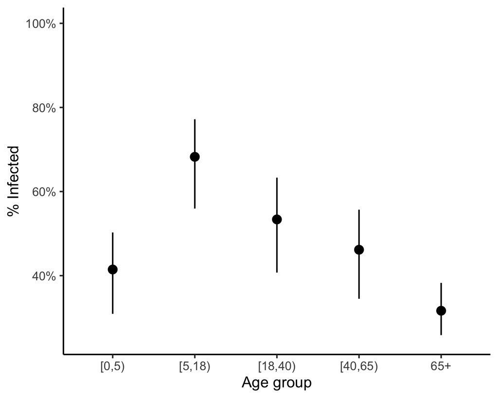

Figure 1: Estimated ranges of the final size of a hypothetical SIR epidemic in age groups of the U.K. population, when the $R_0$ is estimated to be 1.5, with a standard deviation around this estimate of 0.1. In this example, relatively low uncertainty in $R_0$ estimates can also lead to uncertainty in the estimated final size of the epidemic. Points represent means, while ranges extend between the 5th and 95th percentiles.

```r
ggplot(final_size_data) +
  stat_summary(
    aes(
      demo_grp, p_infected
    ),
    fun = mean,
    fun.min = function(x) {
      quantile(x, 0.05)
    },
    fun.max = function(x) {
      quantile(x, 0.95)
    }
  ) +
  scale_y_continuous(
    labels = scales::percent,
    limits = c(0.25, 1)
  ) +
  theme_classic() +
  theme(
    legend.position = "top",
    legend.key.height = unit(2, "mm"),
    legend.title = ggtext::element_markdown(
      vjust = 1
    )
  ) +
  coord_cartesian(
    expand = TRUE
  ) +
  labs(
    x = "Age group",
    y = "% Infected"
  )
```

Mossong, Joël, Niel Hens, Mark Jit, Philippe Beutels, Kari Auranen, Rafael Mikolajczyk, Marco Massari, et al. 2008. “Social Contacts and Mixing Patterns Relevant to the Spread of Infectious Diseases.” *PLOS Medicine* 5 (3): e74. https://doi.org/10.1371/journal.pmed.0050074.